# Fine-scale heterogeneity in Schistosoma mansoni force of infection measured through antibody response

Figure 4a, Figure 4b, Figure S6 seroprevalence and force of infection by distance from Lake Victoria, and age distribution summary

Ben Arnold ben.arnold@ucsf.edu

run 2020-07-24 16:46:41

# Preamble

```r
library(here)
here()
```

```
## [1] "/Users/benarnold/mbita-schisto"
```

```r
#--------------------------------
# source the configuration file
#--------------------------------
source(here("R/mbita-schisto-Config.R"))

#--------------------------------
# source the shared functions file
#--------------------------------
source(here("R/mbita-schisto-Functions.R"))
```

# Load Mbita Kenya antibody measurements and other data

These data include measurements from pre-school aged children in 30 villages near Homa Bay and Mbita in Western Kenya. This article summarizes the study design and field methods:

Won KY, Kanyi HM, Mwende FM, Wiegand RE, Brook Goodhew E, Priest JW, et al. Multiplex Serologic Assessment of Schistosomiasis in Western Kenya: Antibody Responses in Preschool Age Children as a Measure of Reduced Transmission. *Am J Trop Med Hyg.* 2017; 16–0665. https://www.ncbi.nlm.nih.gov/pubmed/28719280

```r
#-----------------------------------
# load the child antibody and
# kato-katz measurements
#-----------------------------------
d <- readRDS(here("data","mbita_schisto.rds")) %>%
  mutate(vid=factor(vid))

#-----------------------------------
# load the village-level spatial
# covariate data, created with
# mbita-schisto-map.Rmd
#
# note: for public-facing workflow
# this file does not include village
# lon/lat to protect participant
# confidentiality
#-----------------------------------
d_spatial <- readRDS(here("data","mbita_spatial.rds")) %>%
  mutate(vid=factor(vid))

d2 <- d %>%
  left_join(d_spatial,by="vid")

# create age strata
# create log values for SEA MFI and KK epg
# convert the dist_victoria variable from class units to numeric
# add a dummy variable for modeling
d2 <- d2 %>%
  mutate(agecat = cut(agey,breaks=c(0,1,2,3,4,6),
                      labels=c("<1 year","1 year","2 years","3 years","4 years")),
         logsea = log10(sea),
         logepg = log10(sm_epg),
         dist_victoria = as.numeric(dist_victoria),
         dummy=1
         )

#-----------------------------------
# load village-level FOI estimates
# estimated in the notebook
# mbita-schisto-SEA-vs_KK.Rmd
#-----------------------------------
d_foi <- readRDS(here("data","mbita-village-foi.rds")) %>%
  rename(lambda = mufoi, lambda_se = mufoi_se, lambda_lb = mufoi_lb, lambda_ub = mufoi_ub) %>%
  mutate(vid = factor(vid))

#-----------------------------------
# create a village-level summary
# dataset of spatial covariates,
# prevalence, and FOI for making figures
#-----------------------------------
dvil <- d2 %>%
  group_by(vid, arm) %>%
  summarize(sea_n = sum(sea_pos,na.rm=T),
            sea_N = sum(ifelse(!is.na(sea_pos),1,0)),
            kk_n = sum(kk_pos,na.rm=T),
            kk_N = sum(ifelse(!is.na(kk_pos),1,0)),
            .groups = "keep"
            ) %>%
  mutate(sea_prev = sea_n/sea_N,
         kk_prev = kk_n/kk_N)

# estimate exact binomial CIs for prevalence
dvil <- dvil %>%
    rowwise() %>%
    mutate(sea_CI = list(enframe(binom.test(x=sea_n, n=sea_N, alternative =  "two.sided", conf.level = 0.95)$conf.int))) %>%
    unnest(sea_CI) %>%
    spread(name, value) %>%
    rename("sea_prev_lb" = "1", "sea_prev_ub" = "2")
dvil <- dvil %>%
    rowwise() %>%
    mutate(kk_CI = list(enframe(binom.test(x=kk_n, n=kk_N, alternative =  "two.sided", conf.level = 0.95)$conf.int))) %>%
    unnest(kk_CI) %>%
    spread(name, value) %>%
    rename("kk_prev_lb" = "1", "kk_prev_ub" = "2")

# join FOI estimates
dvil2 <- left_join(dvil,d_foi,by="vid")

# join spatial covariates
dvil3 <- left_join(dvil2,d_spatial,by="vid") %>%
  mutate(dist_victoria = as.numeric(dist_victoria))
```

# Assess whether age-standarization is necessary

Age is strongly related to both SEA seroprevalence and Kato-Katz prevalence. If age distributions differ across villages, then that could lead to confounding when assessing the relationships between village-level prevalence and other exposures, like distance to the lake Estimate a binomial generalized additive model that includes a cubic spline for child age and village-level random effects. Estimate predicted prevalence in each village, marginally standardized to the age distribution of the entire study population.

```r
#------------------------------
# estimate GAM models for SEA
# and Kato-Katz prevalence
#------------------------------
seafit <- gam(sea_pos ~ s(agey, bs="cr") + s(vid, bs = "re"), data = d2, family = "binomial")
kkfit <- gam(kk_pos ~ s(agey, bs="cr") + s(vid, bs = "re"), data = d2, family = "binomial")

#------------------------------
# create a new dataset that
# reflects the overall age distribution
# and predict prevalence for each village
#------------------------------
d_agest <- foreach(vidi = levels(d2$vid), .combine = rbind) %do% {
  di <- d2 %>% mutate(vid = vidi)
  di$sea_pred = predict(seafit, newdata = di, type = "response")
  di$kk_pred = predict(kkfit, newdata = di, type = "response")
  di
}
d_agest <- d_agest %>%
  mutate(vid = factor(vid,levels=levels(dvil2$vid)),
         vidf = paste0("community ",vid),
         vidf = factor(vidf, levels = paste0("community ",levels(dvil2$vid))))
#------------------------------
# estimate village-level
# age-standardized prevalence
# (marginal standardization)
#------------------------------
dvil_std <- d_agest %>%
  group_by(vid) %>%
  summarize(sea_prev_gam = mean(sea_pred),
            kk_prev_gam = mean(kk_pred),
            .groups = "keep"
            )

#------------------------------
# merge to the unstandardized
# estimates
#------------------------------
dvil_std2 <- left_join(dvil, dvil_std, by = "vid")
```

## Figure S6

Compare unadjusted and age-adjusted prevalence estimates

```r
#--------------------------------
# plot unadjusted versus
# age standardized prevalence
# in the 30 villages
#--------------------------------

#--------------------------------
# SEA
#--------------------------------
plot_unadj_adj_sea <- ggplot(data = dvil_std2, aes(x = sea_prev, y = sea_prev_gam)) +
  geom_abline(intercept = 0, slope = 1, color = "gray60") +
  geom_point(alpha = 0.7, color = vircols[3]) +
  scale_x_continuous(breaks = seq(0,1,by=0.2), labels = sprintf("%1.0f",seq(0,1,by=0.2)*100)) +
  scale_y_continuous(breaks = seq(0,1,by=0.2), labels = sprintf("%1.0f",seq(0,1,by=0.2)*100)) +
  labs(x = "Unadjusted SEA seroprevalence (%)", y = "Age standardized SEA seroprevalence (%)", tag = "B") +
  coord_cartesian(xlim = c(0,1),ylim = c(0,1))


#--------------------------------
# Kato-Katz
#--------------------------------
plot_unadj_adj_kk <- ggplot(data = dvil_std2, aes(x = kk_prev, y = kk_prev_gam)) +
  geom_abline(intercept = 0, slope = 1, color = "gray60") +
  geom_point(alpha = 0.7, color = vircols[3]) +
  scale_x_continuous(breaks = seq(0,1,by=0.2), labels = sprintf("%1.0f",seq(0,1,by=0.2)*100)) +
  scale_y_continuous(breaks = seq(0,1,by=0.2), labels = sprintf("%1.0f",seq(0,1,by=0.2)*100)) +
  labs(x = "Unadjusted Kato-Katz prevalence (%)", y = "Age standardized Kato-Katz prevalence (%)", tag = "C") +
  coord_cartesian(xlim = c(0,1),ylim = c(0,1))
```

Age is not a village-level confounder in this study so ignore it in the analyses below to simplify the estimation process. This is consistent with very similar age distributions across the 30 villages:

```r
d2_plot <- d2 %>%
  mutate(vidf = paste0("community ",vid),
         vidf = factor(vidf, levels = paste0("community ",levels(dvil2$vid))))

plot_age_distributions <- ggplot(data = d2_plot, aes(x = agey)) +
  facet_wrap(~vidf,nrow=6,ncol=5)+
  geom_line(stat = "density", color = vircols[3],lwd=1) +
  geom_rug(color = vircols[3],alpha = 0.2, sides = "b") +
  geom_density(data = d_agest,color = "gray20", lwd=0.3) +
  # geom_line(data = d_agest, stat = "density", color = "gray50", lwd=0.2) +
  labs(x = "age, years", title = "community age distributions", tag = "A")
```

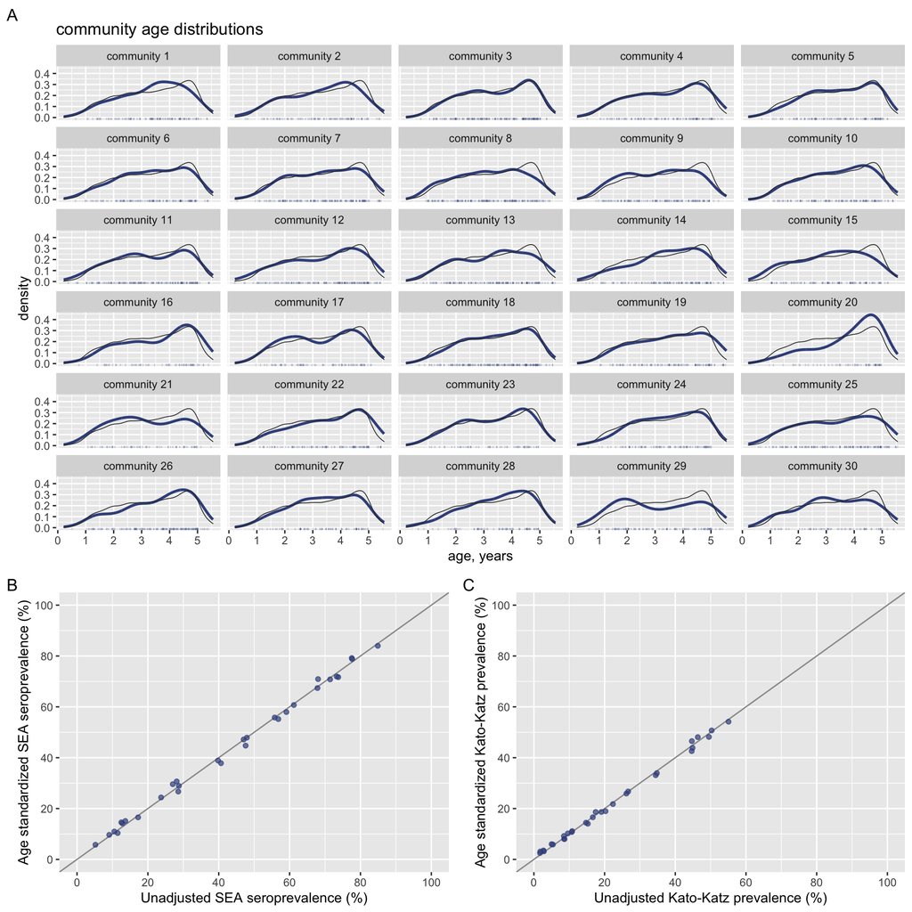

```r
age_plot_composite <- grid.arrange(plot_age_distributions,
                                   plot_unadj_adj_sea,
                                   plot_unadj_adj_kk,
                                   layout_matrix = matrix(c(1,2,1,3), nrow=2),
                                   nrow = 2, ncol = 2,
                                   heights = c(10,6),
                                   widths = c(4,4)
                                   )
```

```r
# save png file
ggsave(filename=here("output","mbita-age-distributions.png"),plot=age_plot_composite,device="png",width=8,height=10)
```

# Village-level seroprevalence and FOI versus distance from the lake

## Fit models of prevalence by distance

Estimate seroprevalence as a function of distance from Lake Victoria using a semi-parametric spline

```r
#-----------------------------
# spline model of SEA seroprevalence
# by distance from the lake
#
# include village-level random
# effects to account for within-
# village correlation
#
# limit predictions to within
# 4km of the lake to reduce
# edge effects from the single
# village that is beyond
#-----------------------------

fit_sea_dist <- mgcv::gam(sea_pos~s(dist_victoria,bs="cr",k=4) +  s(vid,bs="re",by=dummy),
                          family="binomial",
                          data=d2)

newd <- d2 %>%
  group_by(vid) %>%
  filter(dist_victoria < 4000) %>%
  slice(1) %>%
  mutate(dummy=0)
fit_sea_dist_ci <- gamCI(m=fit_sea_dist,newdata=newd,nreps=10000)

# convert linear predictor to prevalance
# (note: expitfn() is in shared functions, source above)
fit_sea_dist_ci <- fit_sea_dist_ci %>%
  mutate(fit = expitfn(fit),
         uprP = expitfn(uprP),
         lwrP = expitfn(lwrP),
         uprS = expitfn(uprS),
         lwrS = expitfn(lwrS),
         )
```

Estimate Kato-Katz prevalence as a function of distance from Lake Victoria using a semi-parametric spline

```r
#-----------------------------
# spline model of SEA seroprevalence
# by distance from the lake
#-----------------------------

fit_kk_dist <- mgcv::gam(kk_pos~s(dist_victoria,bs="cr",k=4) + s(vid,bs="re",by=dummy),
                         family="binomial",
                         data=d2)

newd <- d2 %>%
  group_by(vid) %>%
  slice(1) %>%
  mutate(dummy=0)
fit_kk_dist_ci <- gamCI(m=fit_kk_dist,newdata=newd,nreps=10000)

# convert linear predictor to prevalance
# (note: expitfn() is in shared functions, source above)
fit_kk_dist_ci <- fit_kk_dist_ci %>%
  mutate(fit = expitfn(fit),
         uprP = expitfn(uprP),
         lwrP = expitfn(lwrP),
         uprS = expitfn(uprS),
         lwrS = expitfn(lwrS),
         )
```

Past studies have suggested that many of the highest infection communities are on Rusinga island. Include a random effect for Rusinga island to assess whether the SEA-distance relationship is still statistically significant.

```r
d2 <- d2 %>%
  mutate(rusinga = ifelse(vid %in% c("1","2","3","4","5","8","10","11","15","16","26"),"Yes","No"),
         rusinga = factor(rusinga)
         )

# SEA by distance
fit_sea_dist_island <- mgcv::gam(sea_pos~s(dist_victoria,bs="cr",k=4) +  s(vid,bs="re",by=dummy) + s(rusinga, bs = "re", by = dummy),
                          family="binomial",
                          data=d2)
summary(fit_sea_dist_island)
```

[output not shown]

```r
# compare AIC and BIC with model that excludes island RE
AIC(fit_sea_dist_island,fit_sea_dist)
```

```
##                           df      AIC
## fit_sea_dist_island 27.51053 4141.672
## fit_sea_dist        27.76701 4141.964
```

```r
BIC(fit_sea_dist_island,fit_sea_dist)
```

```
##                           df      BIC
## fit_sea_dist_island 27.51053 4312.403
## fit_sea_dist        27.76701 4314.287
```

## KK prevalence vs. distance

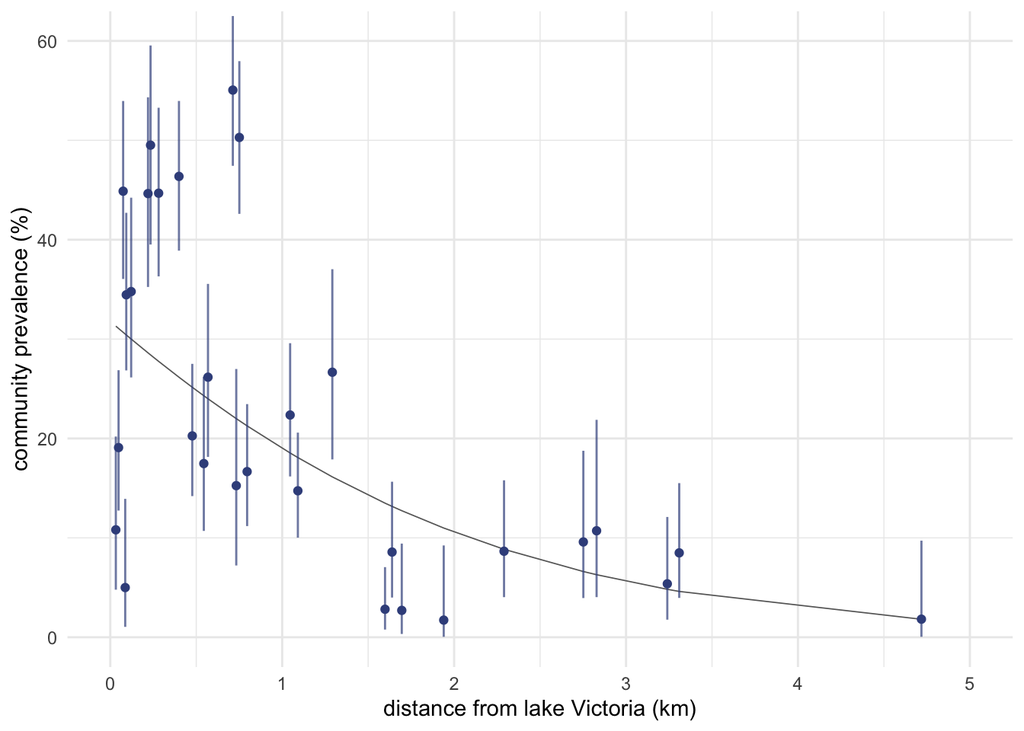

```r
#-----------------------------
# KK prevalence by distance
#-----------------------------
pkkdist <- ggplot(data=fit_kk_dist_ci,aes(x=dist_victoria/1000)) +
  geom_line(aes(y=fit), color="gray40",lwd=0.3) +
  # geom_ribbon(aes(ymin=lwrS,ymax=uprS),alpha=0.1,color=NA,fill="black") +
  geom_errorbar(data=dvil3, aes(x=dist_victoria/1000, ymin= kk_prev_lb, ymax = kk_prev_ub), width=0,color=vircols[3],alpha=0.7) +
  geom_point(data=dvil3,aes(x=dist_victoria/1000,y=kk_prev),alpha=1,color=vircols[3]) +
  scale_y_continuous(breaks=seq(0,1,by=0.2),labels=sprintf("%1.0f",seq(0,1,by=0.2)*100))+
  scale_x_continuous(breaks=0:5)+
  # scale_color_manual(values=pcols)+
  coord_cartesian(ylim=c(0,0.6),xlim=c(0,5)) +
  labs(x="distance from lake Victoria (km)",y="community prevalence (%)") +
  theme_minimal() +
  theme(legend.position="none")
pkkdist
```

## Fig 4a SEA seroprevalence vs. distance

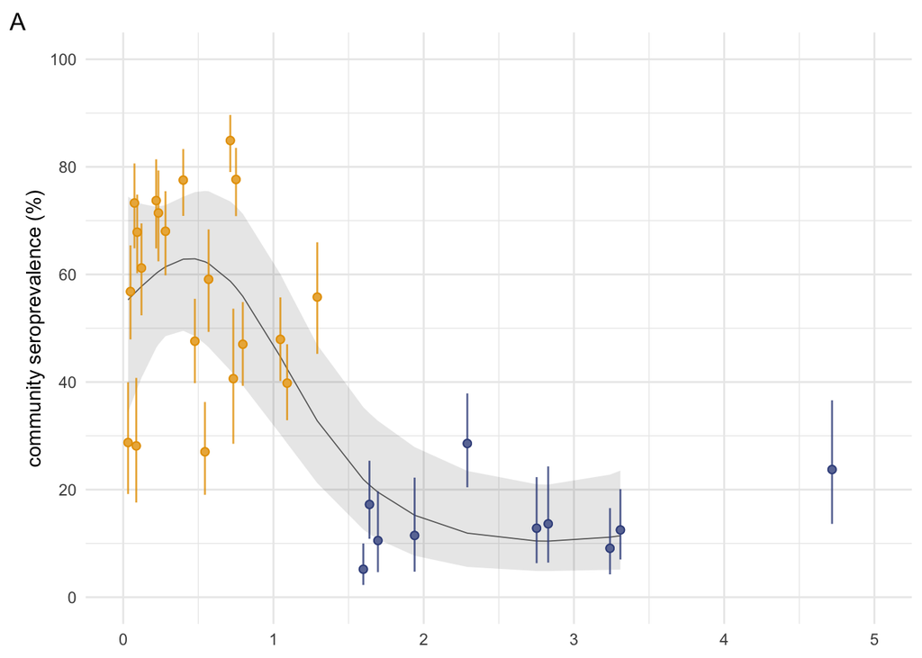

```r
#-----------------------------
# SEA seroprevalence by distance
#
# color village points by <1500
# and >1500m from the lake
# to match age-stratified
# curve figure aesthetics
#-----------------------------
pspdist <- ggplot(data=fit_sea_dist_ci,aes(x=dist_victoria/1000)) +
  # approximate simultaneous confidence interval for the spline fit
  geom_ribbon(aes(ymin=lwrS,ymax=uprS),alpha=0.1,color=NA,fill="black") +
  # spline fit
  geom_line(aes(y=fit), color="gray40",lwd=0.3) +
  # village means, <1500 m
  geom_errorbar(data=filter(dvil3,dist_victoria<1500), aes(x= dist_victoria/1000, ymin = sea_prev_lb, ymax = sea_prev_ub), width = 0, alpha=0.8, color = cbPalette[2])+
  geom_point(data=filter(dvil3,dist_victoria<1500),aes(x= dist_victoria/1000, y = sea_prev), alpha = 1, pch=21, bg="white", color = cbPalette[2], size = 1.75)+
  geom_point(data=filter(dvil3,dist_victoria<1500),aes(x= dist_victoria/1000, y = sea_prev), alpha = 0.8, pch=19, bg=cbPalette[7], color = cbPalette[2], size = 1.75)+
  # village means, >1500 m
  geom_errorbar(data=filter(dvil3,dist_victoria>=1500), aes(x= dist_victoria/1000, ymin = sea_prev_lb, ymax = sea_prev_ub), width = 0, alpha=0.8,color = vircols[3])+
  geom_point(data=filter(dvil3,dist_victoria>=1500),aes(x= dist_victoria/1000, y = sea_prev), alpha = 1, pch=21, bg="white", color = vircols[3], size = 1.75)+
  geom_point(data=filter(dvil3,dist_victoria>=1500),aes(x= dist_victoria/1000, y = sea_prev), alpha = 0.8, pch=19, bg=vircols[3], color = vircols[3], size = 1.75)+
  scale_y_continuous(breaks=seq(0,1,by=0.2),labels=sprintf("%1.0f",seq(0,1,by=0.2)*100))+
  scale_x_continuous(breaks=0:5)+
  # scale_color_manual(values=pcols)+
  coord_cartesian(ylim=c(0,1),xlim=c(0,5)) +
  labs(x=NULL,y="community seroprevalence (%)", tag = "A") +
  theme_minimal() +
  theme(legend.position="none")
pspdist
```

Repeat without the spline fit and 95% CI (too busy, competing 95% CIs for village- vs overall)

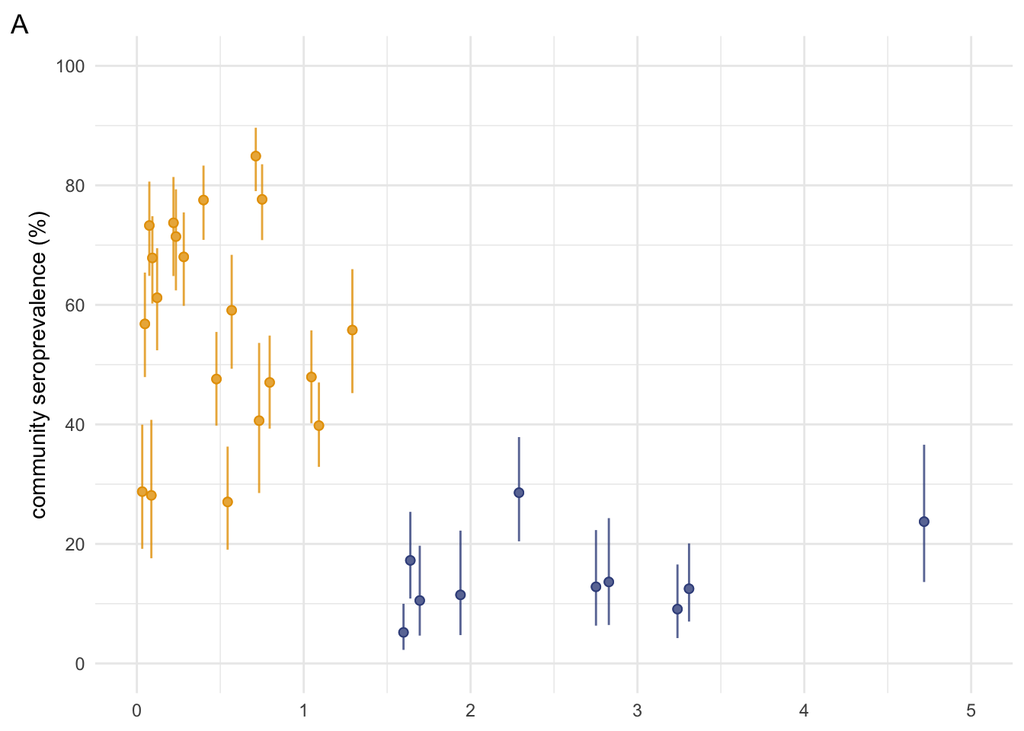

```r
#-----------------------------
# SEA seroprevalence by distance
#
# color village points by <1500
# and >1500m from the lake
# to match age-stratified
# curve figure aesthetics
#-----------------------------
pspdist <- ggplot(data=fit_sea_dist_ci,aes(x=dist_victoria/1000)) +
  # approximate simultaneous confidence interval for the spline fit
  # geom_ribbon(aes(ymin=lwrS,ymax=uprS),alpha=0.1,color=NA,fill="black") +
  # spline fit
  # geom_line(aes(y=fit), color="gray40",lwd=0.3) +
  # village means, <1500 m
  geom_errorbar(data=filter(dvil3,dist_victoria<1500), aes(x= dist_victoria/1000, ymin = sea_prev_lb, ymax = sea_prev_ub), width = 0, alpha=0.8, color = cbPalette[2])+
  geom_point(data=filter(dvil3,dist_victoria<1500),aes(x= dist_victoria/1000, y = sea_prev), alpha = 1, pch=21, bg="white", color = cbPalette[2], size = 1.75)+
  geom_point(data=filter(dvil3,dist_victoria<1500),aes(x= dist_victoria/1000, y = sea_prev), alpha = 0.8, pch=19, bg=cbPalette[7], color = cbPalette[2], size = 1.75)+
  # village means, >1500 m
  geom_errorbar(data=filter(dvil3,dist_victoria>=1500), aes(x= dist_victoria/1000, ymin = sea_prev_lb, ymax = sea_prev_ub), width = 0, alpha=0.8,color = vircols[3])+
  geom_point(data=filter(dvil3,dist_victoria>=1500),aes(x= dist_victoria/1000, y = sea_prev), alpha = 1, pch=21, bg="white", color = vircols[3], size = 1.75)+
  geom_point(data=filter(dvil3,dist_victoria>=1500),aes(x= dist_victoria/1000, y = sea_prev), alpha = 0.8, pch=19, bg=vircols[3], color = vircols[3], size = 1.75)+
  scale_y_continuous(breaks=seq(0,1,by=0.2),labels=sprintf("%1.0f",seq(0,1,by=0.2)*100))+
  scale_x_continuous(breaks=0:5)+
  # scale_color_manual(values=pcols)+
  coord_cartesian(ylim=c(0,1),xlim=c(0,5)) +
  labs(x=NULL,y="community seroprevalence (%)", tag = "A") +
  theme_minimal() +
  theme(legend.position="none")
pspdist
```

## Fig 4b SEA FOI vs. distance

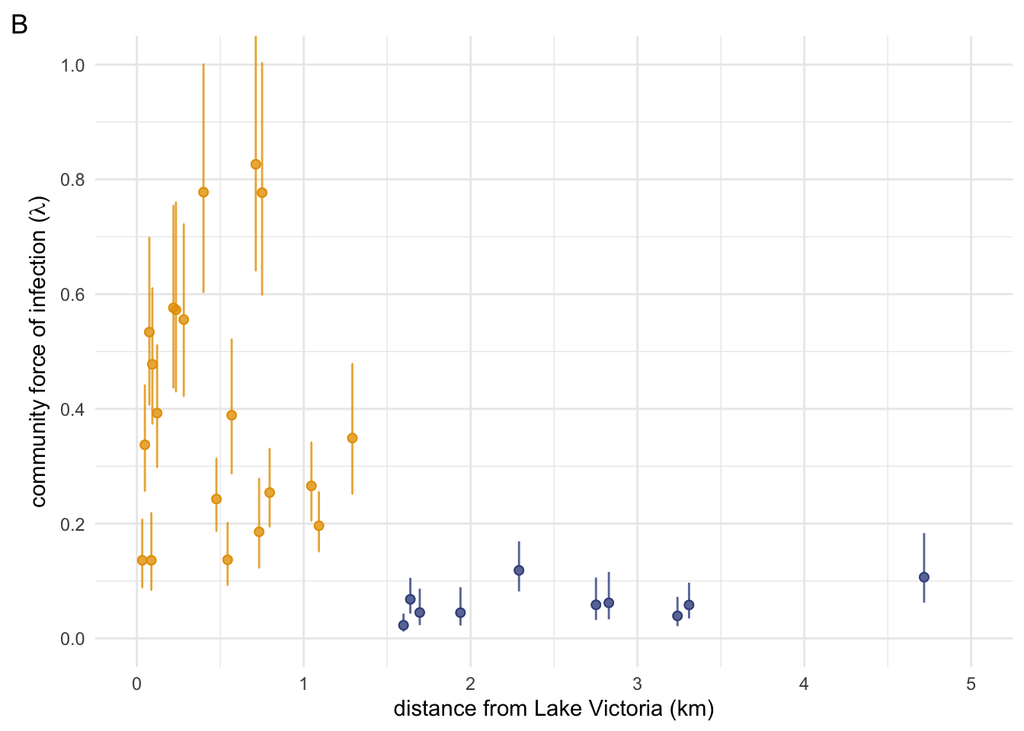

```r
#-----------------------------
# FOI measured by SEA seroconversion over by distance
#-----------------------------
pfoidist <- ggplot(data=dvil3,aes(x=dist_victoria/1000,y=lambda,ymin=lambda_lb,ymax=lambda_ub)) +
  # village mean FOI for villages <1500m
  geom_errorbar(data=filter(dvil3,dist_victoria<1500),alpha=0.8,color = cbPalette[2])+
  geom_point(data=filter(dvil3,dist_victoria<1500),alpha = 1, pch=21, bg="white", color = cbPalette[2], size = 1.75)+
  geom_point(data=filter(dvil3,dist_victoria<1500),alpha = 0.8, pch=19, bg=cbPalette[2], color = cbPalette[2], size = 1.75)+
  # village mean FOI for villages >1500m
  geom_errorbar(data=filter(dvil3,dist_victoria>=1500),width = 0, alpha=0.8,color = vircols[3])+
  geom_point(data=filter(dvil3,dist_victoria>=1500),alpha = 1, pch=21, bg="white", color = vircols[3], size = 1.75)+
  geom_point(data=filter(dvil3,dist_victoria>=1500),alpha = 0.8, pch=19, bg=vircols[3], color = vircols[3], size = 1.75)+
  scale_y_continuous(breaks=seq(0,1,by=0.2))+
  scale_x_continuous(breaks=0:5)+
  # scale_color_manual(values=pcols)+
  coord_cartesian(ylim=c(0,1),xlim=c(0,5)) +
  labs(x="distance from Lake Victoria (km)",y=expression(paste("community force of infection (",lambda,")")), tag = "B") +
  theme_minimal() +
  theme(legend.position="none")
pfoidist
```

## Composite Fig 4a 4b

Create a composite figure for 4a and 4b

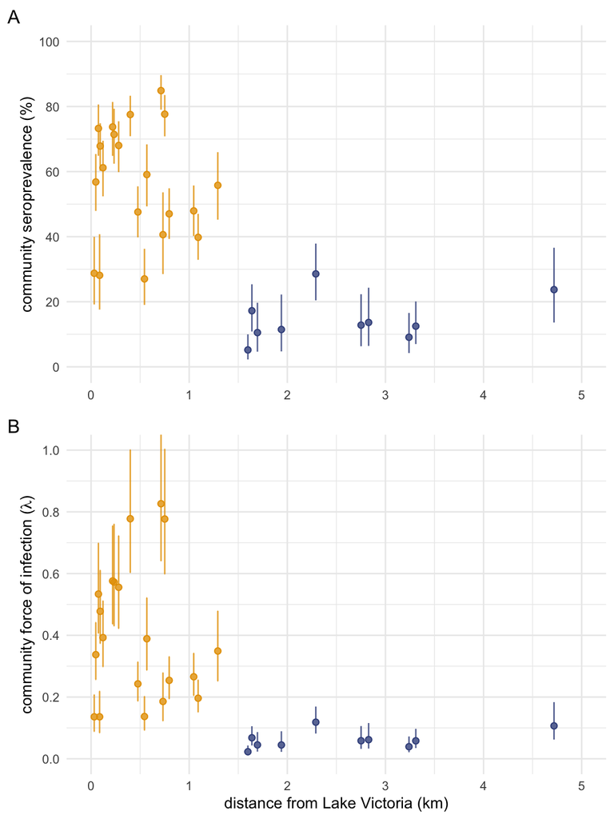

```r
comp_sea_dist <- grid.arrange(pspdist,pfoidist,nrow = 2, ncol = 1)
```

```r
# save png file
ggsave(filename=here("output","mbita-SEA-v-dist.png"),plot=comp_sea_dist,device="png",width=3.42,height=6)

# save pdf file
ggsave(filename=here("output","mbita-SEA-v-dist.pdf"),plot=comp_sea_dist,device="pdf",width=3.42,height=6)
```

# Repeat figures, colored by intervention arm

Repeat the figures above, coloring the points by intervention arm to ensure the patterns are not driven by community-level versus school-based praziquantle distribution

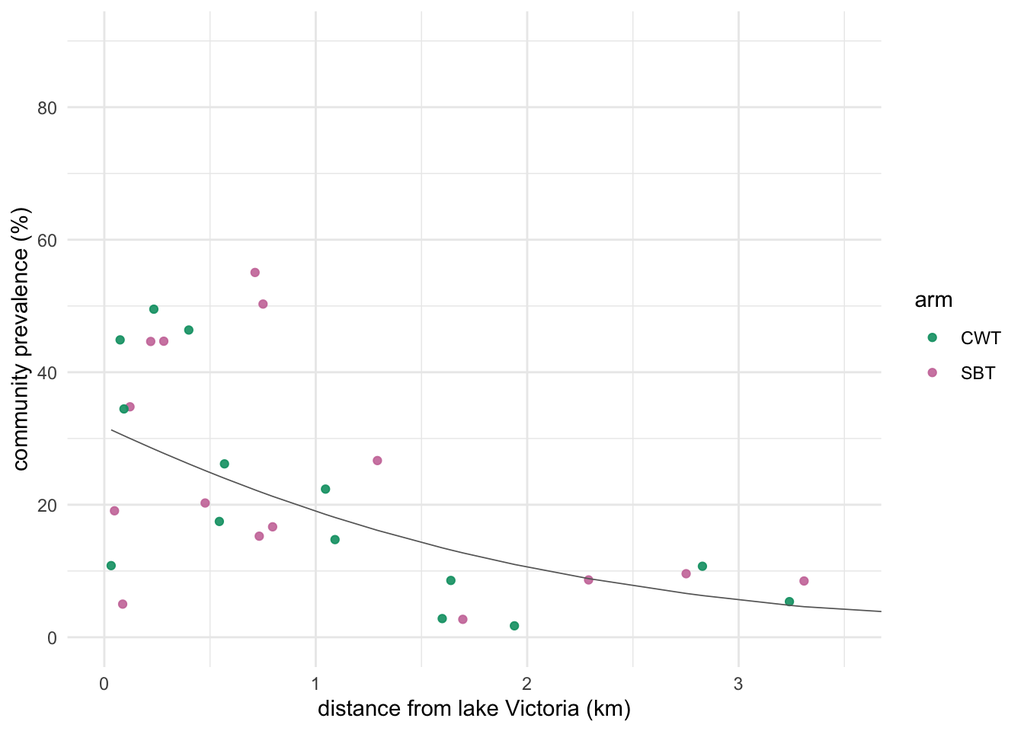

```r
#-----------------------------
# KK prevalence by distance
# points colored by intervention arm
#-----------------------------
pkkdist2 <- ggplot(data=fit_kk_dist_ci,aes(x=dist_victoria/1000,color=arm)) +
  geom_point(data=dvil3,aes(x=dist_victoria/1000,y=kk_prev),alpha=0.9) +
  geom_line(aes(y=fit), color="gray40",lwd=0.3) +
  # geom_ribbon(aes(ymin=lwrP,ymax=uprP),alpha=0.1,color=NA,fill="black") +
  # geom_ribbon(aes(ymin=lwrS,ymax=uprS),alpha=0.1,color=NA,fill="black") +
  scale_y_continuous(breaks=seq(0,1,by=0.2),labels=sprintf("%1.0f",seq(0,1,by=0.2)*100))+
  scale_x_continuous(breaks=0:5)+
  scale_color_manual(values=cbPalette[c(4,8)])+
  coord_cartesian(ylim=c(0,0.9),xlim=c(0,3.5)) +
  labs(x="distance from lake Victoria (km)",y="community prevalence (%)") +
  theme_minimal() +
  theme(legend.position="right")
pkkdist2
```

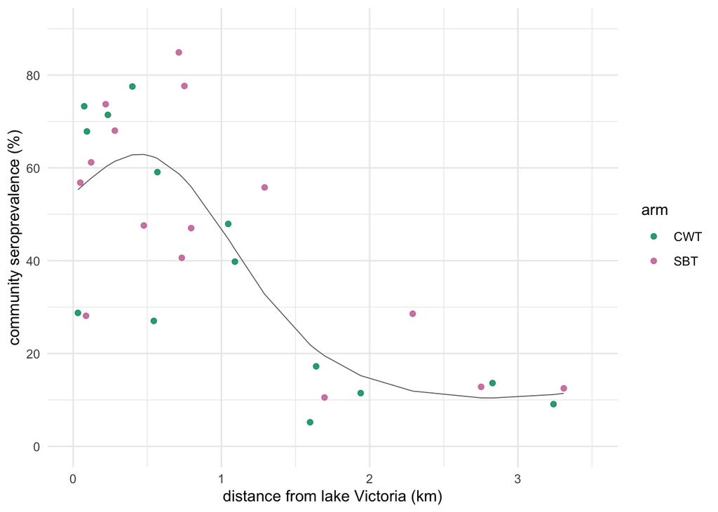

```r
#-----------------------------
# SEA seroprevalence by distance
# points colored by intervention arm
#-----------------------------
pspdist2 <- ggplot(data=fit_sea_dist_ci,aes(x=dist_victoria/1000,color=arm)) +
  geom_point(data=dvil3,aes(x=dist_victoria/1000,y=sea_prev),alpha=0.9) +
  geom_line(aes(y=fit), color="gray40",lwd=0.3) +
  # geom_ribbon(aes(ymin=lwrP,ymax=uprP),alpha=0.1,color=NA,fill="black") +
  # geom_ribbon(aes(ymin=lwrS,ymax=uprS),alpha=0.1,color=NA,fill="black") +
  scale_y_continuous(breaks=seq(0,1,by=0.2),labels=sprintf("%1.0f",seq(0,1,by=0.2)*100))+
  scale_x_continuous(breaks=0:5)+
  scale_color_manual(values=cbPalette[c(4,8)])+
  coord_cartesian(ylim=c(0,0.9),xlim=c(0,3.5)) +
  labs(x="distance from lake Victoria (km)",y="community seroprevalence (%)") +
  theme_minimal() +
  theme(legend.position="right")
pspdist2
```

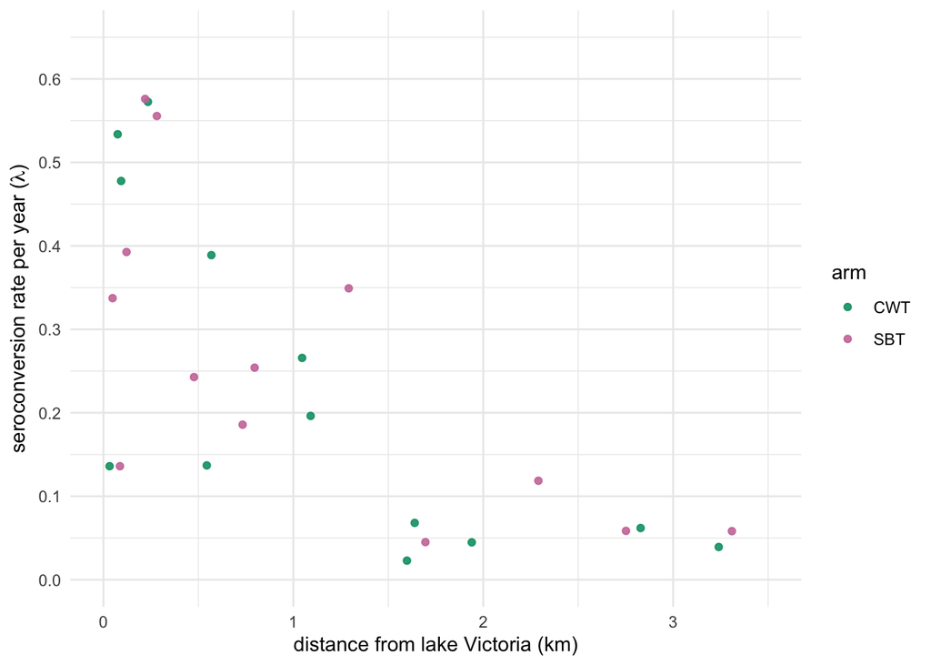

```r
#-----------------------------
# FOI measured by SEA seroconversion over by distance
# points colored by intervention arm
#-----------------------------
pfoidist2 <- ggplot(data=dvil3,aes(x=dist_victoria/1000,y=lambda,color=arm)) +
  geom_point(alpha=0.9) +
  scale_y_continuous(breaks=seq(0,0.6,by=0.1))+
  scale_x_continuous(breaks=0:5)+
  scale_color_manual(values=cbPalette[c(4,8)])+
  coord_cartesian(ylim=c(0,0.65),xlim=c(0,3.5)) +
  labs(x="distance from lake Victoria (km)",y=expression(paste("seroconversion rate per year (",lambda,")"))) +
  theme_minimal() +
  theme(legend.position="right")
pfoidist2
```

# Cumulative cases identified by distance from the lake

Summarize the cumulative number of Kato-Katz positive infections and seropositive children by distance to Lake Victoria.

Note that these curves are influenced by different village sizes, and are not normalized to remove the influence of village size.

They do provide estimates, within this study, of the proportion of infected children identified with different distances from the lake.

As a comparison, we also estimated the proportion of positivies identified by ranking villages by cases and by prevalence, which provide an upper bound of the optimal ranking of villages to identify infected children.

```r
dkkcum <- dvil3 %>%
  dplyr::select(vid, dist_victoria, kk_N, kk_n, kk_prev) %>%
  ungroup()
dkkdist <- dkkcum %>%
  arrange(dist_victoria) %>%
  mutate(vil_rank = row_number(),
         n_tot = sum(kk_n),
         n_cum = cumsum(kk_n),
         p_cum = n_cum / n_tot,
         sorted = "distance") %>%
  dplyr::select(sorted,vid,dist_victoria,kk_prev,vil_rank,n_cum,p_cum)

dkkprev <- dkkcum %>%
  arrange(-kk_prev) %>%
  mutate(vil_rank = row_number(),
         n_tot = sum(kk_n),
         n_cum = cumsum(kk_n),
         p_cum = n_cum / n_tot,
         sorted = "prevalence") %>%
  dplyr::select(sorted,vid,dist_victoria,kk_prev,vil_rank,n_cum,p_cum)

dkkcumd <- bind_rows(dkkdist,dkkprev) %>%
  mutate(sorted = factor(sorted,levels = c("prevalence", "distance")),
         outcome = "Kato-Katz"
         )

dkkn <- dkkcum %>%
  arrange(-kk_n) %>%
  mutate(vil_rank = row_number(),
         n_tot = sum(kk_n),
         n_cum = cumsum(kk_n),
         p_cum = n_cum / n_tot,
         sorted = "cases") %>%
  dplyr::select(sorted,vid,dist_victoria,kk_prev,vil_rank,n_cum,p_cum)

dkkcumd <- bind_rows(dkkdist,dkkprev,dkkn) %>%
  mutate(sorted = factor(sorted,levels = c("cases","prevalence", "distance")),
         outcome = "Kato-Katz"
         )
```

```r
dseacum <- dvil3 %>%
  dplyr::select(vid, dist_victoria, sea_N, sea_n, sea_prev) %>%
  ungroup()
dseadist <- dseacum %>%
  arrange(dist_victoria) %>%
  mutate(vil_rank = row_number(),
         n_tot = sum(sea_n),
         n_cum = cumsum(sea_n),
         p_cum = n_cum / n_tot,
         sorted = "distance") %>%
  dplyr::select(sorted,vid,dist_victoria,sea_prev,vil_rank,n_cum,p_cum)

dseaprev <- dseacum %>%
  arrange(-sea_prev) %>%
  mutate(vil_rank = row_number(),
         n_tot = sum(sea_n),
         n_cum = cumsum(sea_n),
         p_cum = n_cum / n_tot,
         sorted = "prevalence") %>%
  dplyr::select(sorted,vid,dist_victoria,sea_prev,vil_rank,n_cum,p_cum)

dsean <- dseacum %>%
  arrange(-sea_n) %>%
  mutate(vil_rank = row_number(),
         n_tot = sum(sea_n),
         n_cum = cumsum(sea_n),
         p_cum = n_cum / n_tot,
         sorted = "cases") %>%
  dplyr::select(sorted,vid,dist_victoria,sea_prev,vil_rank,n_cum,p_cum)


dseacumd <- bind_rows(dseadist,dseaprev,dsean) %>%
  mutate(sorted = factor(sorted,levels = c("cases","prevalence", "distance")),
         outcome = "SEA"
  )
```

```r
dcum <- bind_rows(dkkcumd, dseacumd)
```

## Figures

Cumulative number of positives stratified by measure (Kato Katz, SEA)

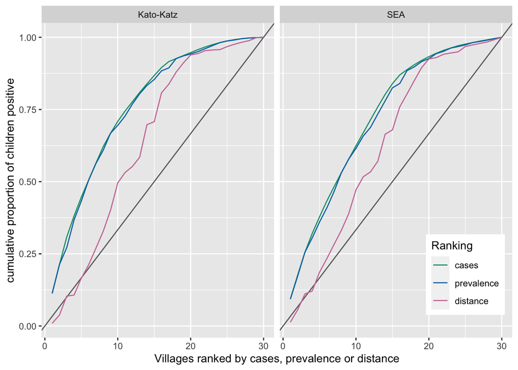

```r
pcols <- cbPalette[c(4,6,8)]
pcumdist <- ggplot(data=dcum, aes(x = vil_rank, y = p_cum, color = sorted)) +
  facet_grid(.~outcome) +
  geom_abline(intercept = 0, slope = 1/30, color = "gray40")+
  geom_line() +
  scale_color_manual(values = pcols, guide = guide_legend(title = "Ranking")) +
  labs(x = "Villages ranked by cases, prevalence or distance", y = "cumulative proportion of children positive") +
  theme(
    legend.position = c(0.9,0.2)
  )

pcumdist
```

Cumulative number of positives stratified by ranking approach (cases, prevalence, distance)

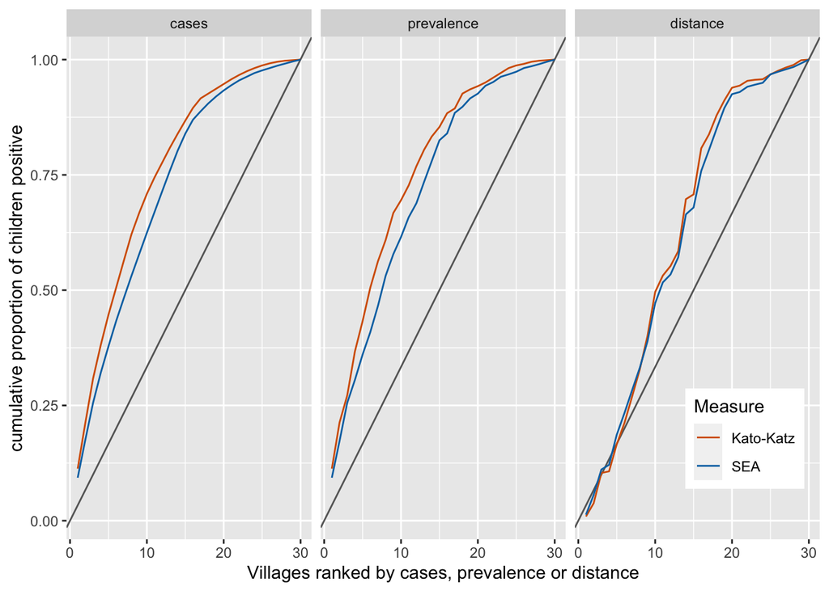

```r
pcols <- cbPalette[c(7,6)]
pcumdist2 <- ggplot(data=dcum, aes(x = vil_rank, y = p_cum, color = outcome)) +
  facet_grid(.~sorted) +
  geom_abline(intercept = 0, slope = 1/30, color = "gray40")+
  geom_line() +
  scale_color_manual(values = pcols, guide = guide_legend(title = "Measure")) +
  labs(x = "Villages ranked by cases, prevalence or distance", y = "cumulative proportion of children positive") +
  theme(
    legend.position = c(0.9,0.2)
  )

pcumdist2
```

## Print estimates for reporting in the manuscript

```r
cum_kk_tab <- dcum %>%
  filter(outcome=="Kato-Katz" & sorted == "distance") %>%
  dplyr::select(vil_rank,dist_victoria,kk_prev,n_cum,p_cum)


knitr::kable(cum_kk_tab,digits = 3) %>%
  kable_styling(bootstrap_options = "striped")
```

| vil_rank | dist_victoria | kk_prev | n_cum | p_cum |
| --- | --- | --- | --- | --- |
| 1 | 32.276 | 0.108 | 8 | 0.009 |
| 2 | 48.141 | 0.191 | 33 | 0.038 |
| 3 | 74.786 | 0.449 | 90 | 0.104 |
| 4 | 86.835 | 0.050 | 93 | 0.107 |
| 5 | 92.978 | 0.345 | 144 | 0.166 |
| 6 | 121.436 | 0.348 | 184 | 0.212 |
| 7 | 219.427 | 0.446 | 234 | 0.269 |
| 8 | 234.207 | 0.495 | 285 | 0.328 |
| 9 | 281.223 | 0.447 | 348 | 0.400 |
| 10 | 399.502 | 0.464 | 431 | 0.496 |
| 11 | 476.861 | 0.203 | 462 | 0.532 |
| 12 | 544.031 | 0.175 | 480 | 0.552 |
| 13 | 568.338 | 0.262 | 508 | 0.585 |
| 14 | 712.821 | 0.551 | 606 | 0.697 |
| 15 | 732.776 | 0.153 | 615 | 0.708 |
| 16 | 750.653 | 0.503 | 702 | 0.808 |
| 17 | 795.959 | 0.167 | 728 | 0.838 |
| 18 | 1046.097 | 0.224 | 764 | 0.879 |
| 19 | 1091.067 | 0.147 | 792 | 0.911 |
| 20 | 1291.539 | 0.267 | 816 | 0.939 |
| 21 | 1598.116 | 0.028 | 820 | 0.944 |
| 22 | 1638.963 | 0.086 | 829 | 0.954 |
| 23 | 1695.457 | 0.027 | 831 | 0.956 |
| 24 | 1939.510 | 0.017 | 832 | 0.957 |
| 25 | 2290.296 | 0.087 | 841 | 0.968 |
| 26 | 2751.608 | 0.096 | 848 | 0.976 |
| 27 | 2828.677 | 0.107 | 854 | 0.983 |
| 28 | 3240.022 | 0.054 | 859 | 0.988 |
| 29 | 3309.313 | 0.085 | 868 | 0.999 |
| 30 | 4718.110 | 0.018 | 869 | 1.000 |

```r
cum_sea_tab <- dcum %>%
  filter(outcome=="SEA" & sorted == "distance") %>%
  dplyr::select(vil_rank,dist_victoria,sea_prev,n_cum,p_cum)

knitr::kable(cum_sea_tab,digits = 3) %>%
  kable_styling(bootstrap_options = "striped")
```

| vil_rank | dist_victoria | sea_prev | n_cum | p_cum |
| --- | --- | --- | --- | --- |
| 1 | 32.276 | 0.288 | 23 | 0.013 |
| 2 | 48.141 | 0.568 | 98 | 0.056 |
| 3 | 74.786 | 0.733 | 194 | 0.111 |
| 4 | 86.835 | 0.281 | 212 | 0.121 |
| 5 | 92.978 | 0.679 | 326 | 0.186 |
| 6 | 121.436 | 0.612 | 408 | 0.233 |
| 7 | 219.427 | 0.737 | 495 | 0.283 |
| 8 | 234.207 | 0.714 | 580 | 0.332 |
| 9 | 281.223 | 0.680 | 680 | 0.389 |
| 10 | 399.502 | 0.775 | 825 | 0.472 |
| 11 | 476.861 | 0.476 | 904 | 0.517 |
| 12 | 544.031 | 0.270 | 934 | 0.534 |
| 13 | 568.338 | 0.591 | 999 | 0.571 |
| 14 | 712.821 | 0.849 | 1162 | 0.664 |
| 15 | 732.776 | 0.406 | 1188 | 0.679 |
| 16 | 750.653 | 0.777 | 1327 | 0.759 |
| 17 | 795.959 | 0.470 | 1406 | 0.804 |
| 18 | 1046.097 | 0.479 | 1487 | 0.850 |
| 19 | 1091.067 | 0.398 | 1565 | 0.895 |
| 20 | 1291.539 | 0.558 | 1618 | 0.925 |
| 21 | 1598.116 | 0.052 | 1626 | 0.930 |
| 22 | 1638.963 | 0.172 | 1646 | 0.941 |
| 23 | 1695.457 | 0.105 | 1654 | 0.946 |
| 24 | 1939.510 | 0.115 | 1661 | 0.950 |
| 25 | 2290.296 | 0.286 | 1693 | 0.968 |
| 26 | 2751.608 | 0.128 | 1703 | 0.974 |
| 27 | 2828.677 | 0.136 | 1712 | 0.979 |
| 28 | 3240.022 | 0.091 | 1721 | 0.984 |
| 29 | 3309.313 | 0.125 | 1735 | 0.992 |
| 30 | 4718.110 | 0.237 | 1749 | 1.000 |